# Bonanza Creek Snowshoe Hares: Exploratory Report

Anastasia Kunz

11/16/2020

Anastasia Kunz

## 3. Exploratory Findings

### A. Annual Juvenile Hare Trap Counts

In 1999 we see the most juvenile hares trapped with a maximum count of 126 juvenile hares. However in two years, 2002 and 2009, there was a minimum count value where no juvenile hares were observed. The trend in Figure 1. shows a steep overall decline in juvenile hare populations, with semi-consistent yearly fluctuations. It is important to note the consistency of days each year that hares were recorded. In some years there are significantly more days in which data is recorded than in other years. For example, only 19 observations were recorded in 2002 with only 3 observations including age. Similarly, age of the hares is inconsistently reported, so it is difficult to comment on population trends without age assessment of the hares that were trapped. In addition, duplicate individuals were recorded both between traps as well as observation duplication. For better total count analysis, there should be consistency in the number of trapping days and number of traps set.

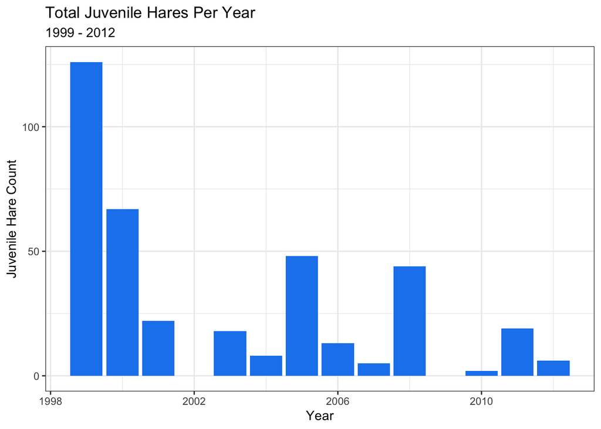

**Figure 1.** Total juvenile hares recorded per year at all trapping sites in Bonanza Creek, Alaska. The 1999 had a maximum hare count of 126, while both 2002 and 2009 had 0 juvenile hare observations. There is an overall decrease in juvenile hare counts for this study period. Data: Kielland et al. 2017.

### B. Visualize Juvenille Hare Weights

In Figure 2, visualization of female and male juvenile hare weights show that for the riparian and mature Bonanza trapping locations, the male juvenile hares have a greater weight than females. However in the black spruce trapping location, differences in male and female juvenile hare weight is much smaller than in the other two trapping locations. It is important to note that in the riparian trapping area, there are also hares trapped with no sex recorded that have a much smaller weight than either the recorded males or females.

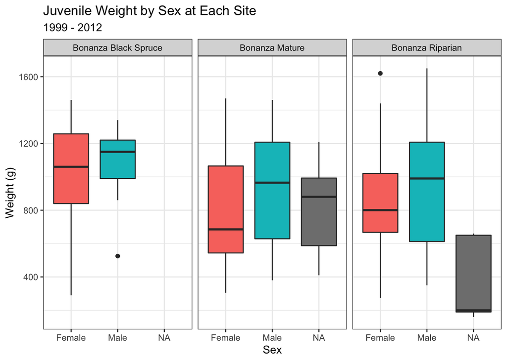

**Figure 2.** Box and whisker plot showing weight(g) of juvenile female, male, and NA Snowshoe hares in Bonanza Creek, Alaska. Plots are separated out by trapping site at Bonanza Black Spruce, Bonanza Riparian, or Bonanza Mature locations. Data: Kielland et al. 2017.

### C. Juvenile Weight Comparison (Male & Female)

**Table 1.** Descriptive statistics (mean, standard deviation, and sample size) comparing juvenile male and female Snowshoe hares. Data: Kielland et al. 2017.

| Sex | Mean Weight (g) | Standard Deviation (g) | Sample Size |
| --- | --- | --- | --- |
| Female | 855.3909 | 292.2526 | 200 |
| Male | 945.8589 | 333.2151 | 163 |

Juvenile hare mean weight (g) were compared between male and female hares. This statistical analysis shows that when comparing mean juvenile hare weight, males (945.86g, n = 163) were larger than females (855.39g, n = 200) with an actual difference in means of 90.47g. This shows a a 10.05% difference (Table 1). Statistical analysis using a two sample t-test showed this difference to be significant (Welches Two Sample T-Test: t(2.71) p = 0.01), with a small effect size (Cohen’s d = 0.29).

### D. Relationship Between Juvenile Weight and Hind Foot Length

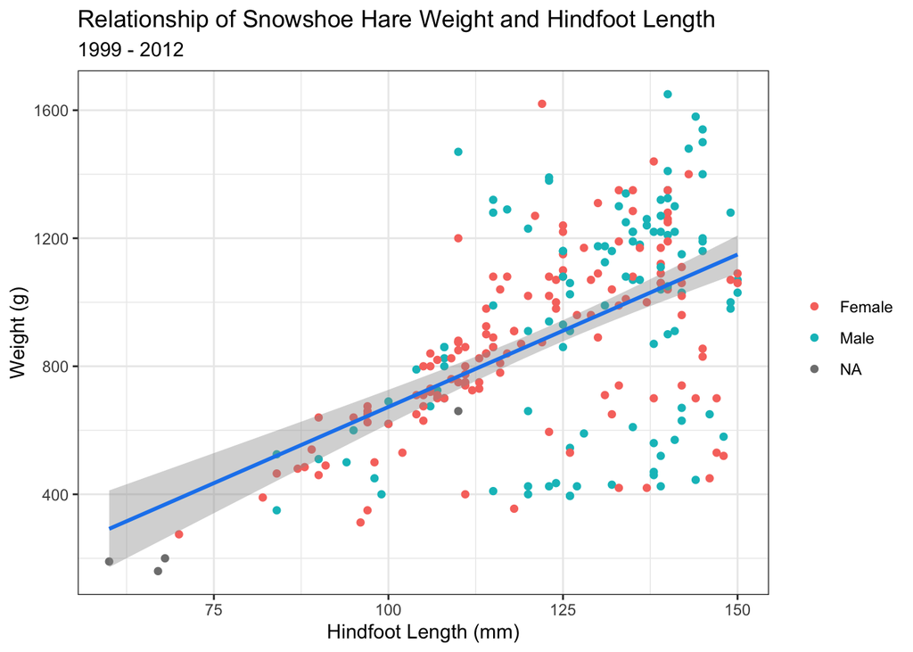

## 5. Citations

1. Kielland, K., F.S. Chapin, R.W. Ruess, and Bonanza Creek LTER. 2017. Snowshoe hare physical data in Bonanza Creek Experimental Forest: 1999-Present ver 22. Environmental Data Initiative. https://doi.org/10.6073/pasta/03dce4856d79b91557d8e6ce2cbcdc14